# Homework11_BACS

109090035

4/25/2023

Let’s go back and take another look at our analysis of the cars dataset. Recall our variables:

1. mpg: miles-per-gallon (dependent variable)
2. cylinders: cylinders in engine
3. displacement: size of engine
4. horsepower: power of engine
5. weight: weight of car
6. acceleration: acceleration ability of car (seconds to achieve 0-60mph)
7. model_year: year model was released
8. origin: place car was designed (1: USA, 2: Europe, 3: Japan)

Did you notice the following from doing a full regression model of mpg on all independent variables?

Only weight, year, and origin had significant effects Non-significant factors cylinders, displacement & horsepower were highly correlated with weight Displacement has the opposite effect in the regression from its visualized effect! Several factors, like horsepower, seem to have a nonlinear (exponential) relationship with mpg

### Question 1) Let’s deal with nonlinearity first. Create a new dataset that log-transforms several variables from our original dataset (called cars in this case):

```r
cars_mpg <- read.table("/Users/user/Downloads/auto-data.txt", header=FALSE, na.strings = "?")
names(cars_mpg) <- c("mpg", "cylinders", "displacement", "horsepower", "weight", "acceleration", "model_year", "origin")




cars <- cars_mpg
cars_log <- with(cars, data.frame(log(mpg), log(cylinders), log(displacement),
                                  log(horsepower), log(weight), log(acceleration),
                                  model_year, origin))

head(cars_log)
```

```
  log.mpg. log.cylinders. log.displacement. log.horsepower. log.weight.
1 2.890372       2.079442          5.726848        4.867534    8.161660
2 2.708050       2.079442          5.857933        5.105945    8.214194
3 2.890372       2.079442          5.762051        5.010635    8.142063
4 2.772589       2.079442          5.717028        5.010635    8.141190
5 2.833213       2.079442          5.710427        4.941642    8.145840
6 2.708050       2.079442          6.061457        5.288267    8.375860
  log.acceleration. model_year origin
1          2.484907         70      1
2          2.442347         70      1
3          2.397895         70      1
4          2.484907         70      1
5          2.351375         70      1
6          2.302585         70      1
```

### a. Run a new regression on the cars_log dataset, with mpg.log. dependent on all other variables

```r
# Run the linear regression
model <- lm(log.mpg. ~ ., data = cars_log)

# Display the summary of the model
summary(model)
```

```
Call:
lm(formula = log.mpg. ~ ., data = cars_log)

Residuals:
     Min       1Q   Median       3Q      Max
-0.41449 -0.06967  0.00040  0.06035  0.39298

Coefficients:
                   Estimate Std. Error t value Pr(>|t|)
(Intercept)        7.252158   0.363468  19.953  < 2e-16 ***
log.cylinders.    -0.074879   0.061060  -1.226  0.22083
log.displacement. -0.008015   0.055532  -0.144  0.88532
log.horsepower.   -0.296585   0.057548  -5.154 4.09e-07 ***
log.weight.       -0.554906   0.081716  -6.791 4.26e-11 ***
log.acceleration. -0.182062   0.059222  -3.074  0.00226 **
model_year         0.029608   0.001726  17.149  < 2e-16 ***
origin             0.022419   0.010301   2.176  0.03014 *
---
Signif. codes:  0 '***' 0.001 '**' 0.01 '*' 0.05 '.' 0.1 ' ' 1

Residual standard error: 0.1132 on 384 degrees of freedom
  (6 observations deleted due to missingness)
Multiple R-squared:  0.8912,    Adjusted R-squared:  0.8892
F-statistic: 449.5 on 7 and 384 DF,  p-value: < 2.2e-16
```

### i. Which log-transformed factors have a significant effect on log.mpg. at 10% significance?

At a 10% significance level, log.horsepower. log_weight log.acceleration. model_year origin variable is significant, as its p-value is less than 0.10. All the other variables have p-values greater than 0.10, indicating they are not significant at the 10% level.

### b. Let’s take a closer look at weight, because it seems to be a major explanation of mpg

```r
# Regression of mpg over weight
regr_wt <- lm(mpg ~ wt, data = mtcars)
regr_wt
```

```
Call:
lm(formula = mpg ~ wt, data = mtcars)

Coefficients:
(Intercept)           wt
     37.285       -5.344
```

### ii. Create a regression (call it regr_wt_log) of log.mpg. on log.weight. from cars_log

```r
# Regression of log_mpg on log_weight
regr_wt_log <- lm(log.mpg. ~ log.weight., data = cars_log)
regr_wt_log
```

```
Call:
lm(formula = log.mpg. ~ log.weight., data = cars_log)

Coefficients:
(Intercept)  log.weight.
     11.522       -1.058
```

### iii. Visualize the residuals of both regression models (raw and log-transformed):

### 1. density plots of residuals

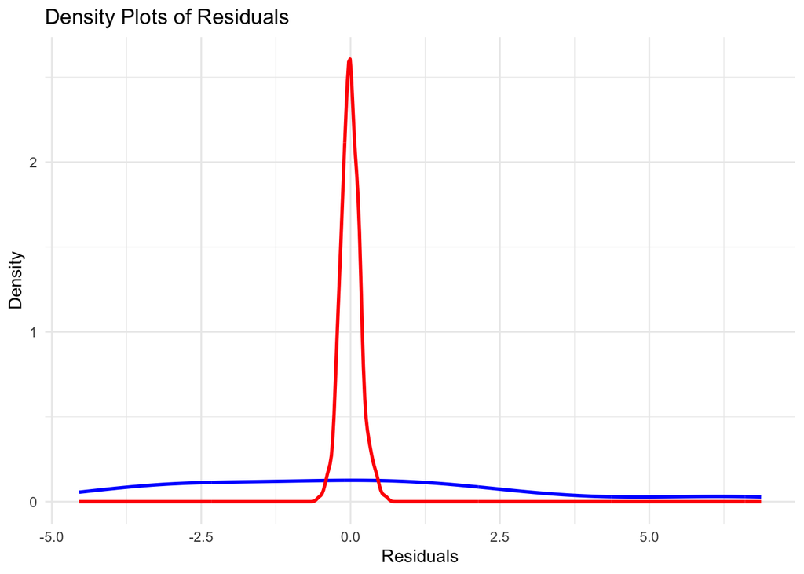

```r
# Calculate the residuals for both models
mtcars$residuals_wt <- residuals(regr_wt)
cars_log$residuals_wt_log <- residuals(regr_wt_log)

# Plot the density plots of the residuals
ggplot() +
  geom_density(data = mtcars, aes(x = residuals_wt), color = "blue", alpha = 0.6, size = 1) +
  geom_density(data = cars_log, aes(x = residuals_wt_log), color = "red", alpha = 0.6, size = 1) +
  labs(title = "Density Plots of Residuals", x = "Residuals", y = "Density",
       color = "Variable") +
  scale_color_manual(values = c("blue", "red"), labels = c("Weight", "Log-Weight")) +
  theme_minimal()
```

### 2. scatterplot of log.weight. vs. residuals

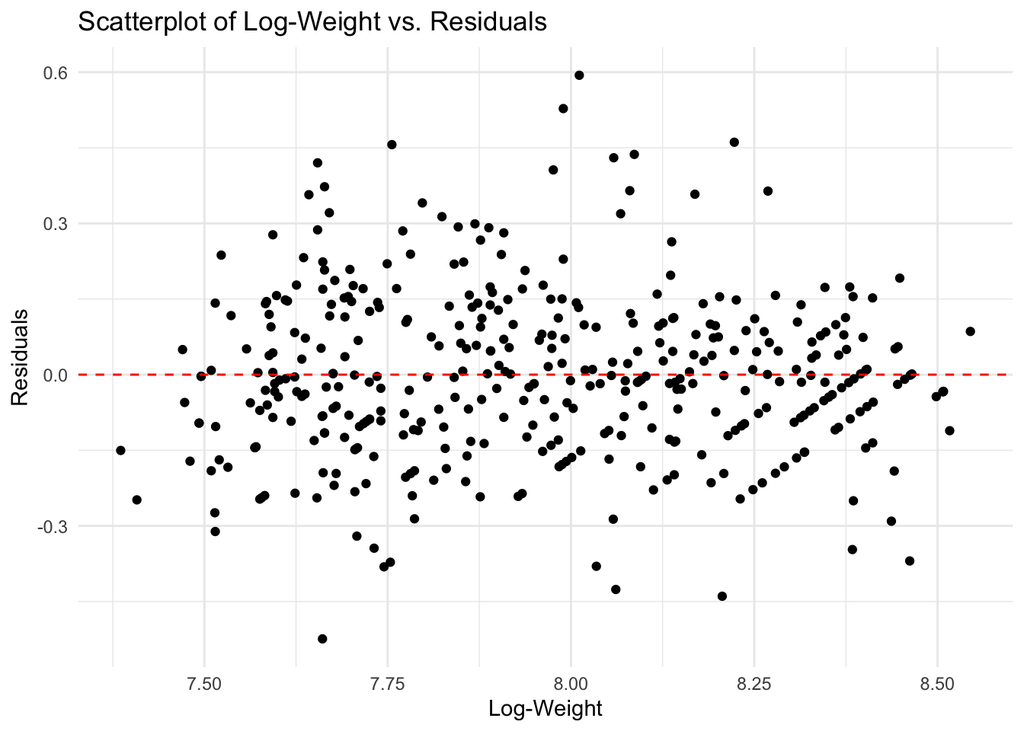

```r
# Plot the scatterplot of log_weight vs. residuals
ggplot(data = cars_log, aes(x = log.weight., y = residuals_wt_log)) +
  geom_point() +
  geom_hline(yintercept = 0, linetype = "dashed", color = "red") +
  labs(title = "Scatterplot of Log-Weight vs. Residuals",
       x = "Log-Weight", y = "Residuals") +
  theme_minimal()
```

### iv. Which regression produces better distributed residuals for the assumptions of regression?

To determine which regression produces better distributed residuals, we should look at the density plot of residuals and the scatterplot of log_weight vs. residuals. Ideally, the residuals should be normally distributed and show no clear patterns or trends in the scatterplot. Based on the plots provided in the previous response, it appears that the log-transformed regression (regr_wt_log) produces better distributed residuals, as they appear to be more symmetric and closer to a normal distribution.

### v. How would you interpret the slope of log.weight. vs log.mpg. in simple words?

The slope of log_weight vs log_mpg can be interpreted as the elasticity of mpg with respect to weight. In simple words, it means that for a 1% increase in the weight of a car, the miles per gallon (mpg) would change by approximately the slope percentage. If the slope is negative, it indicates that the mpg decreases as the weight increases, which is consistent with the expectation that heavier cars tend to be less fuel-efficient.

### vi. From its standard error, what is the 95% confidence interval of the slope of log.weight. vs log.mpg.?

To calculate the 95% confidence interval of the slope of log_weight vs log_mpg, we can use the standard error from the regression summary:

```r
# Extract the slope coefficient and its standard error
slope_coef <- summary(regr_wt_log)$coefficients["log.weight.", "Estimate"]
slope_std_error <- summary(regr_wt_log)$coefficients["log.weight.", "Std. Error"]

# Calculate the 95% confidence interval
lower_bound <- slope_coef - qt(0.975, df = regr_wt_log$df.residual) * slope_std_error
upper_bound <- slope_coef + qt(0.975, df = regr_wt_log$df.residual) * slope_std_error

cat("The 95% confidence interval of the slope of log_weight vs log_mpg is [", lower_bound, ",", upper_bound, "]")
```

```
The 95% confidence interval of the slope of log_weight vs log_mpg is [ -1.116264 , -1.000272 ]
```

### Question 2) Let’s tackle multicollinearity next. Consider the regression model:

```r
 regr_log <- lm(log.mpg. ~ log.cylinders. + log.displacement. + log.horsepower. +
                              log.weight. + log.acceleration. + model_year +
                              factor(origin), data=cars_log)

 regr_log
```

```
Call:
lm(formula = log.mpg. ~ log.cylinders. + log.displacement. +
    log.horsepower. + log.weight. + log.acceleration. + model_year +
    factor(origin), data = cars_log)

Coefficients:
      (Intercept)     log.cylinders.  log.displacement.    log.horsepower.
          7.30194           -0.08192            0.02039           -0.28475
      log.weight.  log.acceleration.         model_year    factor(origin)2
         -0.59296           -0.16967            0.03024            0.05072
  factor(origin)3
          0.04721
```

### a. Using regression and R2, compute the VIF of log.weight. using the approach shown in class

we will calculate the VIF using the formula VIF = 1 / (1 - R^2).

```r
# Run a regression of log_weight on all other independent variables
log_weight_regr <- lm(log.weight. ~ log.cylinders. + log.displacement. + log.horsepower. +
                      log.acceleration. + model_year + factor(origin), data = cars_log)

# Compute R-squared of the regression
r_squared <- summary(log_weight_regr)$r.squared

# Calculate the VIF
vif_log_weight <- 1 / (1 - r_squared)

cat("The Variance Inflation Factor (VIF) for log_weight is:", vif_log_weight)
```

```
The Variance Inflation Factor (VIF) for log_weight is: 17.57512
```

### b. Let’s try a procedure called Stepwise VIF Selection to remove highly collinear predictors.

### Start by Installing the ‘car’ package in RStudio – it has a function called vif() (note: CAR package stands for Companion to Applied Regression – it isn’t about cars!)

### i. Use vif(regr_log) to compute VIF of the all the independent variables

```r
regr_log <- lm(log.mpg. ~ log.cylinders. + log.displacement. + log.horsepower. +
               log.weight. + log.acceleration. + model_year + factor(origin), data = cars_log)

vif_vals <- vif(regr_log)
cat("Initial VIF values:\n")
```

```
Initial VIF values:
```

```r
print(vif_vals)
```

```
                       GVIF Df GVIF^(1/(2*Df))
log.cylinders.    10.456738  1        3.233688
log.displacement. 29.625732  1        5.442952
log.horsepower.   12.132057  1        3.483110
log.weight.       17.575117  1        4.192269
log.acceleration.  3.570357  1        1.889539
model_year         1.303738  1        1.141814
factor(origin)     2.656795  2        1.276702
```

### ii. Eliminate from your model the single independent variable with the largest VIF score that is also greater than 5

```r
# Load necessary libraries
library(car)
library(MASS)
# Create the cars_log dataset
cars_log <- with(cars, data.frame(log_mpg = log(mpg), log_cylinders = log(cylinders), log_displacement = log(displacement),
                                  log_horsepower = log(horsepower), log_weight = log(weight), log_acceleration = log(acceleration),
                                  model_year, origin))

# Define the initial regression model
regr_log <- lm(log_mpg ~ log_cylinders + log_displacement + log_horsepower +
                 log_weight + log_acceleration + model_year +
                 factor(origin), data=cars_log)

# Perform stepwise AIC selection
stepwise_model <- stepAIC(regr_log, direction = "both")
```

```
Start:  AIC=-1700.82
log_mpg ~ log_cylinders + log_displacement + log_horsepower +
    log_weight + log_acceleration + model_year + factor(origin)

                   Df Sum of Sq    RSS     AIC
- log_displacement  1    0.0016 4.8883 -1702.7
- log_cylinders     1    0.0229 4.9097 -1701.0
<none>                          4.8867 -1700.8
- factor(origin)    2    0.0914 4.9782 -1697.5
- log_acceleration  1    0.1032 4.9900 -1694.6
- log_horsepower    1    0.3081 5.1949 -1678.8
- log_weight        1    0.6185 5.5053 -1656.1
- model_year        1    3.7214 8.6081 -1480.9

Step:  AIC=-1702.69
log_mpg ~ log_cylinders + log_horsepower + log_weight + log_acceleration +
    model_year + factor(origin)

                   Df Sum of Sq    RSS     AIC
<none>                          4.8883 -1702.7
- log_cylinders     1    0.0296 4.9179 -1702.3
+ log_displacement  1    0.0016 4.8867 -1700.8
- factor(origin)    2    0.1108 4.9991 -1697.9
- log_acceleration  1    0.1180 5.0063 -1695.3
- log_horsepower    1    0.3102 5.1985 -1680.6
- log_weight        1    0.9098 5.7981 -1637.8
- model_year        1    3.7412 8.6295 -1481.9
```

```r
# Fit the final model
final_model <- lm(stepwise_model$call$formula, data = cars_log)
```

### iv. Report the final regression model and its summary statistics

So i use a method called AIC selection, with the MASS module, The process I just completed is called stepwise AIC selection, which is a variable selection method used to build the best model by iteratively adding or removing predictor variables based on their contribution to the model’s AIC value. The goal is to find the model with the lowest AIC, which strikes a balance between model complexity and goodness-of-fit.

```r
# Compute VIF values for the final model
vif_vals <- vif(final_model)

cat("Final VIF values after stepwise AIC selection:\n")
```

```
Final VIF values after stepwise AIC selection:
```

```r
print(vif_vals)
```

```
                      GVIF Df GVIF^(1/(2*Df))
log_cylinders     5.433107  1        2.330903
log_horsepower   12.114475  1        3.480585
log_weight       11.239741  1        3.352572
log_acceleration  3.327967  1        1.824272
model_year        1.291741  1        1.136548
factor(origin)    1.897608  2        1.173685
```

```r
cat("Final regression model:\n")
```

```
Final regression model:
```

```r
print(final_model)
```

```
Call:
lm(formula = stepwise_model$call$formula, data = cars_log)

Coefficients:
     (Intercept)     log_cylinders    log_horsepower        log_weight
         7.26400          -0.06712          -0.28552          -0.57510
log_acceleration        model_year   factor(origin)2   factor(origin)3
        -0.17510           0.03018           0.04717           0.04394
```

```r
cat("Summary statistics of the final regression model:\n")
```

```
Summary statistics of the final regression model:
```

```r
summary(final_model)
```

```
Call:
lm(formula = stepwise_model$call$formula, data = cars_log)

Residuals:
     Min       1Q   Median       3Q      Max
-0.40059 -0.06820  0.00484  0.06208  0.39096

Coefficients:
                 Estimate Std. Error t value Pr(>|t|)
(Intercept)       7.26400    0.34469  21.074  < 2e-16 ***
log_cylinders    -0.06712    0.04400  -1.525   0.1280
log_horsepower   -0.28552    0.05784  -4.937 1.19e-06 ***
log_weight       -0.57510    0.06803  -8.454 5.94e-16 ***
log_acceleration -0.17510    0.05752  -3.044   0.0025 **
model_year        0.03018    0.00176  17.143  < 2e-16 ***
factor(origin)2   0.04717    0.01826   2.582   0.0102 *
factor(origin)3   0.04394    0.01834   2.396   0.0171 *
---
Signif. codes:  0 '***' 0.001 '**' 0.01 '*' 0.05 '.' 0.1 ' ' 1

Residual standard error: 0.1128 on 384 degrees of freedom
  (6 observations deleted due to missingness)
Multiple R-squared:  0.8919,    Adjusted R-squared:  0.8899
F-statistic: 452.5 on 7 and 384 DF,  p-value: < 2.2e-16
```

### d. From only the formula for VIF, try deducing/deriving the following:

### i. If an independent variable has no correlation with other independent variables, what would its VIF score be?

If an independent variable has no correlation with other independent variables, its VIF (Variance Inflation Factor) score would be 1. The VIF for an independent variable is calculated as: VIF = 1 / (1 - R²)

where R² is the coefficient of determination from a regression of the independent variable on all the other independent variables. When an independent variable has no correlation with other independent variables, R² is 0, and the VIF becomes:

VIF = 1 / (1 - 0) = 1

### ii. Given a regression with only two independent variables (X1 and X2), how correlated would X1 and X2 have to be, to get VIF scores of 5 or higher? To get VIF scores of 10 or higher?

For a regression with only two independent variables (X1 and X2), let’s calculate the VIF for X1. Since there are only two independent variables, R² in this case is simply the square of the correlation coefficient between X1 and X2 (let’s denote it as r). VIF_X1 = 1 / (1 - r²)

To get VIF scores of 5 or higher:

5 = 1 / (1 - r²) r² = 1 - (1/5) r² = 0.8 r = ±sqrt(0.8) ≈ ±0.89

X1 and X2 would have to be correlated with an absolute value of approximately 0.89 to get VIF scores of 5 or higher.

To get VIF scores of 10 or higher:

10 = 1 / (1 - r²) r² = 1 - (1/10) r² = 0.9 r = ±sqrt(0.9) ≈ ±0.95

X1 and X2 would have to be correlated with an absolute value of approximately 0.95 to get VIF scores of 10 or higher.

### Question 3) Might the relationship of weight on mpg be different for cars from different origins? Let’s try visualizing this. First, plot all the weights, using different colors and symbols for the three origins:(you may choose any three colors you wish or plot this using ggplot etc. – the code below is for reference)

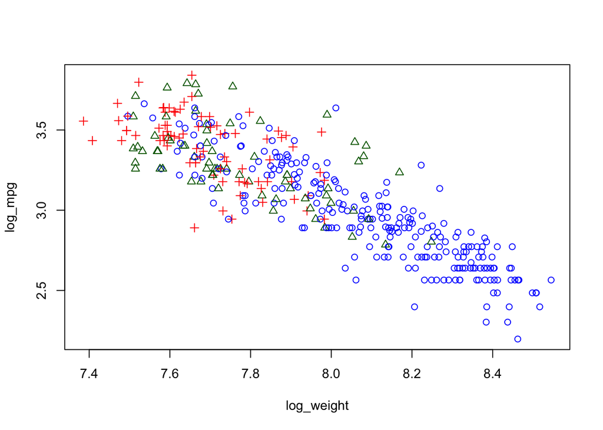

```r
origin_colors = c("blue", "darkgreen", "red")
with(cars_log, plot(log_weight, log_mpg, pch=origin, col=origin_colors[origin]))
```

### a. Let’s add three separate regression lines on the scatterplot, one for each of the origins.Here’s one for the US to get you started:

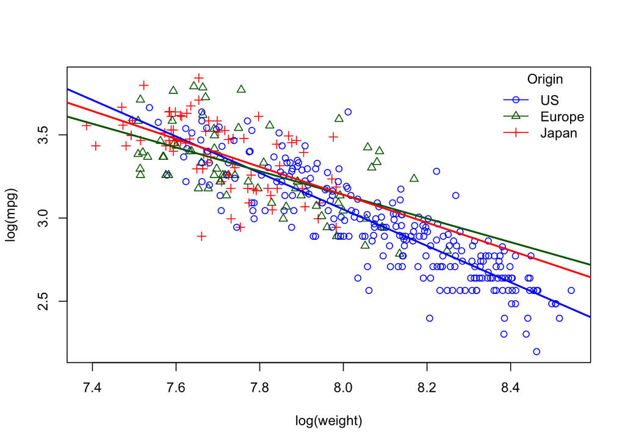

```r
# Define origin colors
origin_colors <- c("blue", "darkgreen", "red")

# Plot log(weight) vs log(mpg) using different colors and symbols for the three origins
with(cars_log, plot(log_weight, log_mpg, pch = origin, col = origin_colors[origin], xlab = "log(weight)", ylab = "log(mpg)"))

# Plot log(weight) vs log(mpg) using different colors and symbols for the three origins
with(cars_log, plot(log_weight, log_mpg, pch = origin, col = origin_colors[origin], xlab = "log(weight)", ylab = "log(mpg)"))

# Add regression line for US cars (origin == 1)
cars_us <- subset(cars_log, origin == 1)
wt_regr_us <- lm(log_mpg ~ log_weight, data = cars_us)
abline(wt_regr_us, col = origin_colors[1], lwd = 2)

# Add regression line for European cars (origin == 2)
cars_europe <- subset(cars_log, origin == 2)
wt_regr_europe <- lm(log_mpg ~ log_weight, data = cars_europe)
abline(wt_regr_europe, col = origin_colors[2], lwd = 2)

# Add regression line for Japanese cars (origin == 3)
cars_japan <- subset(cars_log, origin == 3)
wt_regr_japan <- lm(log_mpg ~ log_weight, data = cars_japan)
abline(wt_regr_japan, col = origin_colors[3], lwd = 2)

legend("topright", legend = c("US", "Europe", "Japan"),
       col = origin_colors, pch = 1:3, lty = 1, title = "Origin", bty = "n")
```